# ADS 506 Final Team Project: U.S. Retail Sales Forecasting

Cross-Vertical Analysis: Health & Personal Care, Clothing, Building Materials, and Macro Retail

Group 8: Mia Arnold, Jordan Blackman, Ramin Fazli

2026-11-21

# 1 Project Overview & Objectives

In applied retail forecasting, supply chain planners must constantly balance inventory availability with carrying costs. Retail demand is characterized by pronounced annual seasonality, holiday promotional spikes, and macroeconomic sensitivity.

We analyze and forecast across three distinct retail verticals and one aggregated macro composite:

1. **Defensive / Essential Staple:** *Health & Personal Care Stores* (`MRTSSM446USN` - NAICS 446)
2. **Discretionary / Cyclical:** *Clothing & Accessories Stores* (`MRTSSM448USN` - NAICS 448)
3. **Housing-Linked / Seasonal:** *Building Material & Garden Equipment Dealers* (`MRTSSM444USN` - NAICS 444)
4. **Macro Retail Composite:** Aggregate total across all three sectors ($Y_{\text{macro}} = Y_{\text{health}} + Y_{\text{clothing}} + Y_{\text{building}}$).

To control for monetary inflation and evaluate real consumer purchasing volume, we integrate the **Consumer Price Index for All Urban Consumers (`CPIAUCNS`)**.

# 2 Libraries & Environment Setup

```r
# Core tidy time series libraries
library(tidyverse)
library(fpp3)
library(scales)
library(zoo)
library(slider)
library(gt)

# Set clean visualization theme
theme_set(theme_minimal(base_size = 12))
```

# 3 Data Ingestion & Pipeline

## 3.1 Automated Data Download from FRED

We retrieve all four monthly series directly from FRED using a reliable curl connection.

```r
# Function to download series from FRED via curl
fetch_fred <- function(series_id) {
  cmd <- sprintf('curl -sL "https://fred.stlouisfed.org/graph/fredgraph.csv?id=%s"', series_id)
  df <- read.csv(pipe(cmd), stringsAsFactors = FALSE)
  names(df) <- c("date", "value")
  df$value <- suppressWarnings(as.numeric(df$value))
  df$date <- as.Date(df$date)
  return(df)
}

# Define explicit study window boundaries to guarantee 100% reproducibility
# (Prevents dynamic data additions or Census Bureau revisions from altering project metrics)
STUDY_START <- as.Date("1992-01-01")
STUDY_END   <- as.Date("2026-08-01") # Latest complete month across all MRTS series

# Fetch the 3 retail verticals and CPI
health_raw   <- fetch_fred("MRTSSM446USN") |> rename(health = value)
clothing_raw <- fetch_fred("MRTSSM448USN") |> rename(clothing = value)
building_raw <- fetch_fred("MRTSSM444USN") |> rename(building = value)
cpi_raw      <- fetch_fred("CPIAUCNS")    |> rename(cpi = value)
```

## 3.2 Missing Value Diagnostics & Imputation

Before modeling, we inspect all series for missing timestamps or values (`NA`).

```r
# Check missing value counts in raw downloads across respective columns
c(
  health_na       = sum(is.na(health_raw$health)),
  clothing_na     = sum(is.na(clothing_raw$clothing)),
  building_na     = sum(is.na(building_raw$building)),
  cpi_na_post1992 = sum(is.na(cpi_raw$cpi[cpi_raw$date >= as.Date("1992-01-01")]))
)
```

```
##       health_na     clothing_na     building_na cpi_na_post1992
##               0               0               0               1
```

```r
# Display the exact timestamp where CPI has a missing observation
cpi_raw |> filter(is.na(cpi), date >= as.Date("1992-01-01"))
```

```
##         date cpi
## 1 2025-10-01  NA
```

In the raw FRED release for `CPIAUCNS`, the observation for **October 2025** is missing (`NA`). To maintain an unbroken monthly time series without gaps, we impute this single value using **linear interpolation** (`zoo::na.approx`).

```r
# Impute the single missing CPI observation using linear interpolation
cpi_clean <- cpi_raw |>
  mutate(cpi = na.approx(cpi, na.rm = FALSE))

# Confirm zero missing values remain
cat("Missing values in CPI after interpolation:", sum(is.na(cpi_clean$cpi[cpi_clean$date >= as.Date("1992-01-01")])), "\n")
```

```
## Missing values in CPI after interpolation: 0
```

## 3.3 CPI Deflation & Macro Retail Aggregation

We merge the datasets, calculate:

1. **Real Sales Volume** (adjusted for inflation): $\text{Sales}_{\text{Real}} = \frac{\text{Sales}_{\text{Nominal}}}{\text{CPI}} \times 100$

2. **Macro Retail Series**: Sum of all three series in each month.

```r
# Merge into wide format
retail_wide <- health_raw |>
  inner_join(clothing_raw, by = "date") |>
  inner_join(building_raw, by = "date") |>
  inner_join(cpi_clean, by = "date") |>
  filter(date >= STUDY_START, date <= STUDY_END) |>
  mutate(
    macro_retail = health + clothing + building,
    Month = yearmonth(date)
  )

# Reshape into a unified tidy table ready for tsibble forecasting
retail_tidy <- retail_wide |>
  select(Month, cpi, health, clothing, building, macro_retail) |>
  pivot_longer(
    cols = c(health, clothing, building, macro_retail),
    names_to = "vertical",
    values_to = "sales_nominal"
  ) |>
  mutate(
    # Human-readable labels for facets/plots
    vertical_name = case_when(
      vertical == "health"       ~ "Health & Personal Care",
      vertical == "clothing"     ~ "Clothing & Accessories",
      vertical == "building"     ~ "Building & Garden Supplies",
      vertical == "macro_retail" ~ "Macro Retail Total (Combined)"
    ),
    # CPI Deflated Real Sales (Constant 1982-84 Dollars)
    sales_real = (sales_nominal / cpi) * 100,
    # Natural Log Transform (for multiplicative variance stabilization)
    log_sales_nominal = log(sales_nominal),
    log_sales_real    = log(sales_real)
  )

# Convert to tsibble
retail_ts <- retail_tidy |>
  as_tsibble(index = Month, key = vertical)

# Verify no gaps exist
cat("Any implicit time gaps in tsibble:", any(has_gaps(retail_ts)$.gaps), "\n")
```

```
## Any implicit time gaps in tsibble: FALSE
```

## 3.4 Trading-Day Calendar Regressors

Because these series are not seasonally adjusted, monthly sales depend partly on the calendar: a month with five Saturdays sells more than one with four, even with identical demand (Fildes et al., 2022). We count each weekday in every month and express Monday through Saturday relative to Sunday, plus the number of days in the month. These regressors are fixed calendar facts, so they are known for any future month and can be used by TSLM, ARIMAX, and the forecasting dashboard without extra data.

```r
# Number of times weekday k (1 = Sunday ... 7 = Saturday) occurs in each month
count_wday <- function(month, k) {
  start <- as.Date(month)
  n_days <- lubridate::days_in_month(start)
  vapply(seq_along(start),
         function(i) sum(lubridate::wday(start[i] + 0:(n_days[i] - 1)) == k),
         numeric(1))
}

# Adds trading-day regressors to any tsibble with a yearmonth `Month` index
add_trading_days <- function(data) {
  data |>
    mutate(
      td_mon = count_wday(Month, 2) - count_wday(Month, 1),
      td_tue = count_wday(Month, 3) - count_wday(Month, 1),
      td_wed = count_wday(Month, 4) - count_wday(Month, 1),
      td_thu = count_wday(Month, 5) - count_wday(Month, 1),
      td_fri = count_wday(Month, 6) - count_wday(Month, 1),
      td_sat = count_wday(Month, 7) - count_wday(Month, 1),
      days_in_month = as.numeric(lubridate::days_in_month(as.Date(Month)))
    )
}

retail_ts <- retail_ts |> add_trading_days()

retail_ts |>
  as_tibble() |>
  filter(vertical == "health", Month >= yearmonth("2026 Jan")) |>
  select(Month, starts_with("td_"), days_in_month) |>
  knitr::kable(caption = "Trading-day regressors (first months of 2026)")
```

Trading-day regressors (first months of 2026)

| Month | td_mon | td_tue | td_wed | td_thu | td_fri | td_sat | days_in_month |
| --- | --- | --- | --- | --- | --- | --- | --- |
| 2026 Jan | 0 | 0 | 0 | 1 | 1 | 1 | 31 |
| 2026 Feb | 0 | 0 | 0 | 0 | 0 | 0 | 28 |
| 2026 Mar | 0 | 0 | -1 | -1 | -1 | -1 | 31 |
| 2026 Apr | 0 | 0 | 1 | 1 | 0 | 0 | 30 |
| 2026 May | -1 | -1 | -1 | -1 | 0 | 0 | 31 |
| 2026 Jun | 1 | 1 | 0 | 0 | 0 | 0 | 30 |
| 2026 Jul | 0 | 0 | 1 | 1 | 1 | 0 | 31 |
| 2026 Aug | 0 | -1 | -1 | -1 | -1 | 0 | 31 |

## 3.5 Export Clean Dataset

We save the processed tidy dataset to `data/retail_data_clean.csv` for use by the Shiny application and team members.

```r
# Ensure data directory exists and write CSV
if (!dir.exists("data")) dir.create("data", recursive = TRUE)
write_csv(as_tibble(retail_ts), "data/retail_data_clean.csv")
```

## 3.6 Data Quality Assessment & Descriptive Statistics Profile

To satisfy the Module 4 Data Quality Assessment criteria, we generate a formal statistical profile evaluating completeness, distribution spreads, and time series strength features.

```r
# 1. Comprehensive Data Quality Profile
quality_summary <- retail_ts |>
  as_tibble() |>
  group_by(`Retail Vertical` = vertical_name) |>
  summarise(
    `Start Month`     = format(min(Month), "%Y %b"),
    `End Month`       = format(max(Month), "%Y %b"),
    `Total N`         = n(),
    `Missing (NA)`    = sum(is.na(sales_nominal)),
    `Mean ($M)`       = mean(sales_nominal),
    `Median ($M)`     = median(sales_nominal),
    `Std Dev ($M)`    = sd(sales_nominal),
    `Min ($M)`        = min(sales_nominal),
    `Max ($M)`        = max(sales_nominal),
    `CV (SD/Mean)`    = sd(sales_nominal) / mean(sales_nominal)
  )

quality_summary |>
  gt() |>
  tab_header(
    title = md("**U.S. Retail Sales: Data Quality & Descriptive Statistics Profile**"),
    subtitle = "Monthly Retail Trade Survey (January 1992 – August 2026, NSA)"
  ) |>
  fmt_number(columns = c(`Mean ($M)`, `Median ($M)`, `Std Dev ($M)`, `Min ($M)`, `Max ($M)`), decimals = 1) |>
  fmt_number(columns = `CV (SD/Mean)`, decimals = 3) |>
  cols_align(align = "center", columns = -`Retail Vertical`) |>
  tab_options(
    data_row.padding = px(4),
    heading.title.font.size = "13pt",
    heading.subtitle.font.size = "10pt"
  )
```

**U.S. Retail Sales: Data Quality & Descriptive Statistics Profile**

Monthly Retail Trade Survey (January 1992 – August 2026, NSA)

| Retail Vertical | Start Month | End Month | Total N | Missing (NA) | Mean ($M) | Median ($M) | Std Dev ($M) | Min ($M) | Max ($M) | CV (SD/Mean) |
| --- | --- | --- | --- | --- | --- | --- | --- | --- | --- | --- |
| Building & Garden Supplies | 1992 Jan | 2026 Aug | 416 | 0 | 25,631.4 | 24,133.0 | 10,106.2 | 8,847.0 | 52,820.0 | 0.394 |
| Clothing & Accessories | 1992 Jan | 2026 Aug | 416 | 0 | 17,241.7 | 16,918.5 | 5,989.0 | 2,532.0 | 39,105.0 | 0.347 |
| Health & Personal Care | 1992 Jan | 2026 Aug | 416 | 0 | 20,646.3 | 20,635.0 | 9,032.6 | 6,985.0 | 45,214.0 | 0.437 |
| Macro Retail Total (Combined) | 1992 Jan | 2026 Aug | 416 | 0 | 63,519.4 | 62,500.5 | 23,417.5 | 22,769.0 | 124,304.0 | 0.369 |

```r
# 2. Time Series Feature Diagnostics (STL Trend & Seasonality Strength)
stl_features_summary <- retail_ts |>
  features(sales_nominal, feat_stl) |>
  mutate(
    `Retail Vertical` = case_when(
      vertical == "health"       ~ "Health & Personal Care",
      vertical == "clothing"     ~ "Clothing & Accessories",
      vertical == "building"     ~ "Building & Garden Supplies",
      vertical == "macro_retail" ~ "Macro Retail Total (Combined)"
    )
  ) |>
  select(`Retail Vertical`, `Trend Strength (F_T)` = trend_strength, `Seasonal Strength (F_S)` = seasonal_strength_year)

stl_features_summary |>
  gt() |>
  tab_header(
    title = md("**Time Series Decomposition Feature Strengths**"),
    subtitle = "Quantifying relative magnitude of trend and 12-month annual seasonality (0 to 1 scale)"
  ) |>
  fmt_number(columns = c(`Trend Strength (F_T)`, `Seasonal Strength (F_S)`), decimals = 3) |>
  cols_align(align = "center", columns = -`Retail Vertical`) |>
  tab_options(
    data_row.padding = px(4),
    heading.title.font.size = "13pt",
    heading.subtitle.font.size = "10pt"
  )
```

**Time Series Decomposition Feature Strengths**

Quantifying relative magnitude of trend and 12-month annual seasonality (0 to 1 scale)

| Retail Vertical | Trend Strength (F_T) | Seasonal Strength (F_S) |
| --- | --- | --- |
| Building & Garden Supplies | 0.993 | 0.945 |
| Clothing & Accessories | 0.959 | 0.938 |
| Health & Personal Care | 0.998 | 0.828 |
| Macro Retail Total (Combined) | 0.995 | 0.922 |

## 3.7 Mathematical Transformations: Box-Cox Optimization via Guerrero’s Method

When seasonal swings expand proportionally with sales growth (multiplicative seasonality), variance stabilization is required prior to linear and ARIMA modeling. We estimate the optimal Box-Cox transformation parameter $\lambda$ using **Guerrero’s method**, which minimizes the coefficient of variation across seasonal subseries.

$$\min_\lambda
\frac{\sigma_\text{seasonal}}{\mu_\text{seasonal}}, \quad w_t =
\begin{cases} \log(y_t) & \text{if } \lambda = 0 \\
\frac{y_t^\lambda - 1}{\lambda} & \text{if } \lambda \neq 0
\end{cases}$$

```r
# Estimate optimal lambda via Guerrero's method across all series
lambda_estimates <- retail_ts |>
  features(sales_nominal, features = guerrero) |>
  mutate(
    `Retail Vertical` = case_when(
      vertical == "health"       ~ "Health & Personal Care",
      vertical == "clothing"     ~ "Clothing & Accessories",
      vertical == "building"     ~ "Building & Garden Supplies",
      vertical == "macro_retail" ~ "Macro Retail Total (Combined)"
    ),
    `Guerrero Lambda` = lambda_guerrero,
    `Empirical Interpretation` = case_when(
      abs(lambda_guerrero) < 0.15 ~ "Optimal lambda ≈ 0: Logarithmic transform ln(Y_t) is ideal",
      TRUE ~ "Weak power transform; log transform remains robust & interpretable")) |>
  select(`Retail Vertical`, `Guerrero Lambda`, `Empirical Interpretation`)

lambda_estimates |>
  gt() |>
  tab_header(
    title = md("**Guerrero's Method: Box-Cox Lambda Parameter Estimates**"),
    subtitle = "Evaluating optimal variance-stabilizing power transformation across retail verticals"
  ) |>
  fmt_number(columns = `Guerrero Lambda`, decimals = 4) |>
  cols_align(align = "center", columns = c(`Guerrero Lambda`)) |>
  tab_options(
    data_row.padding = px(4),
    heading.title.font.size = "13pt",
    heading.subtitle.font.size = "10pt"
  )
```

**Guerrero’s Method: Box-Cox Lambda Parameter Estimates**

Evaluating optimal variance-stabilizing power transformation across retail verticals

| Retail Vertical | Guerrero Lambda | Empirical Interpretation |
| --- | --- | --- |
| Building & Garden Supplies | 0.0005 | Optimal lambda ≈ 0: Logarithmic transform ln(Y_t) is ideal |
| Clothing & Accessories | 0.4235 | Weak power transform; log transform remains robust & interpretable |
| Health & Personal Care | 0.2813 | Weak power transform; log transform remains robust & interpretable |
| Macro Retail Total (Combined) | 0.2566 | Weak power transform; log transform remains robust & interpretable |

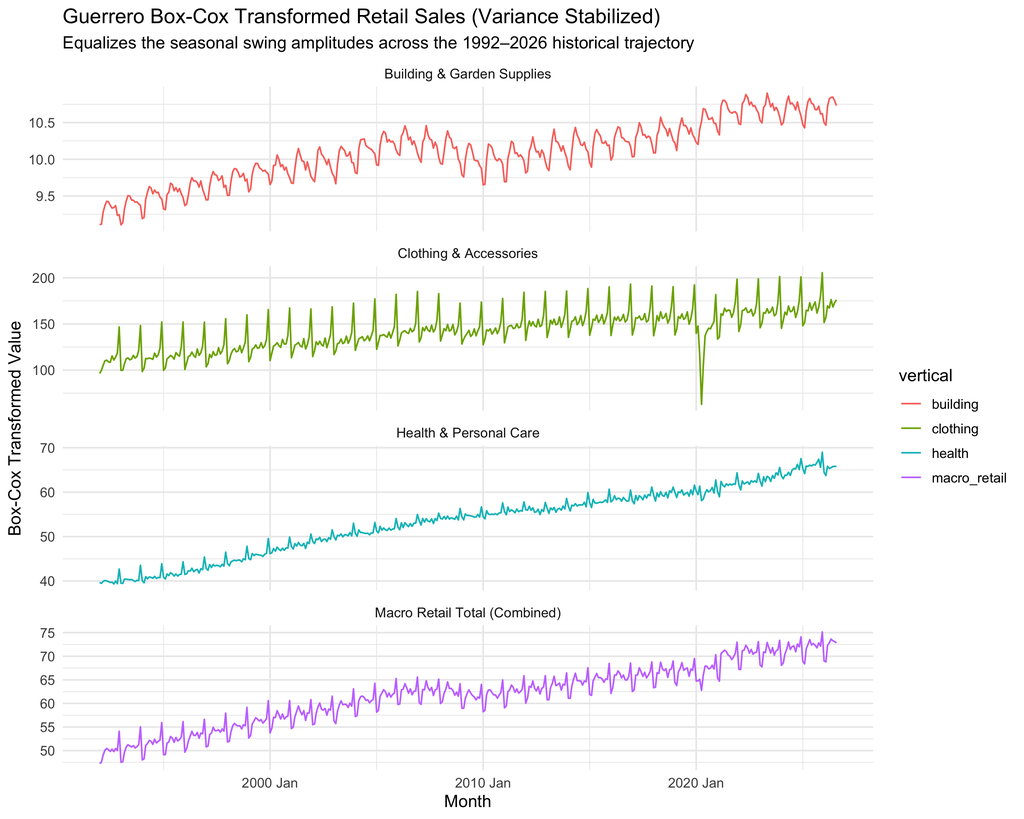

```r
# Plot Box-Cox Transformed Series (stabilized variance)
retail_ts |>
  left_join(retail_ts |> features(sales_nominal, features = guerrero), by = "vertical") |>
  mutate(sales_boxcox = box_cox(sales_nominal, lambda_guerrero)) |>
  autoplot(sales_boxcox) +
  facet_wrap(vars(vertical_name), scales = "free_y", ncol = 1) +
  labs(
    title = "Guerrero Box-Cox Transformed Retail Sales (Variance Stabilized)",
    subtitle = "Equalizes the seasonal swing amplitudes across the 1992–2026 historical trajectory",
    y = "Box-Cox Transformed Value",
    x = "Month"
  )
```

# 4 Exploratory Data Analysis (EDA) & Decomposition

## 4.1 Historical Time Series Trends: Nominal vs. Real Sales

We plot all three individual retail verticals alongside the Macro Retail aggregate.

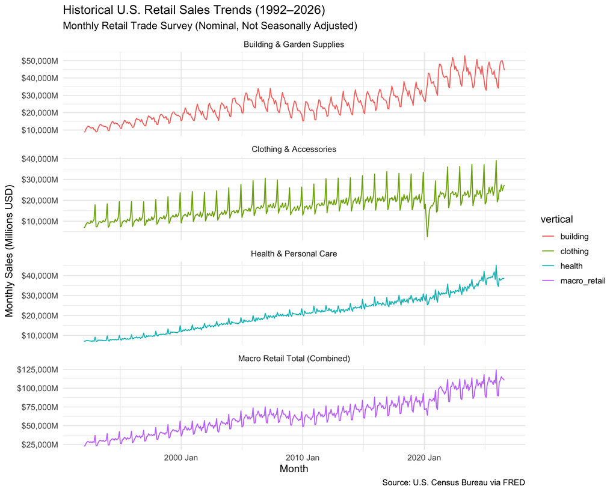

```r
# Plot nominal sales over time across verticals
retail_ts |>
  autoplot(sales_nominal) +
  facet_wrap(vars(vertical_name), scales = "free_y", ncol = 1) +
  scale_y_continuous(labels = dollar_format(suffix = "M")) +
  labs(
    title = "Historical U.S. Retail Sales Trends (1992–2026)",
    subtitle = "Monthly Retail Trade Survey (Nominal, Not Seasonally Adjusted)",
    y = "Monthly Sales (Millions USD)",
    x = "Month",
    caption = "Source: U.S. Census Bureau via FRED"
  )
```

### 4.1.1 Inflation Impact: Nominal vs. Real Purchasing Power

Controlling for inflation with CPI reveals whether recent sales increases represent real volume expansion or price inflation.

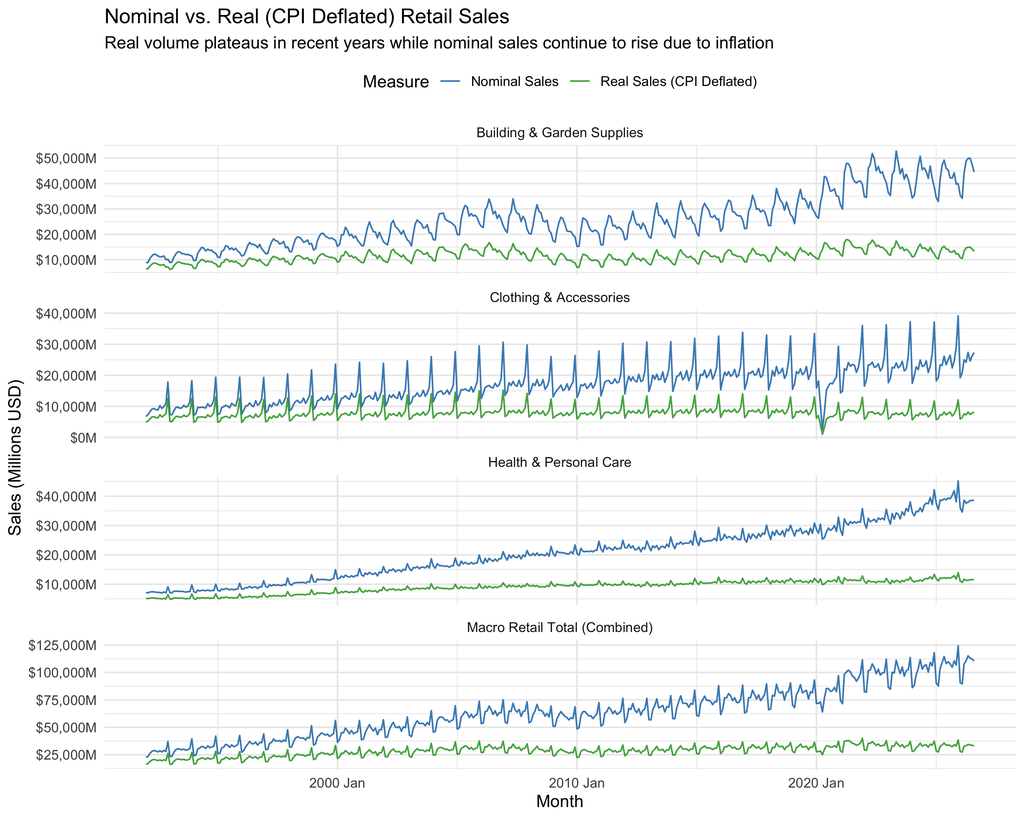

```r
# Compare Nominal vs Real sales for Macro Retail and Verticals
retail_ts |>
  select(Month, vertical_name, sales_nominal, sales_real) |>
  pivot_longer(cols = c(sales_nominal, sales_real), names_to = "series_type", values_to = "sales_val") |>
  mutate(series_label = ifelse(series_type == "sales_nominal", "Nominal Sales", "Real Sales (CPI Deflated)")) |>
  ggplot(aes(x = Month, y = sales_val, color = series_label)) +
  geom_line(alpha = 0.85) +
  facet_wrap(vars(vertical_name), scales = "free_y", ncol = 1) +
  scale_y_continuous(labels = dollar_format(suffix = "M")) +
  scale_color_manual(values = c("Nominal Sales" = "#1f77b4", "Real Sales (CPI Deflated)" = "#2ca02c")) +
  labs(
    title = "Nominal vs. Real (CPI Deflated) Retail Sales",
    subtitle = "Real volume plateaus in recent years while nominal sales continue to rise due to inflation",
    x = "Month",
    y = "Sales (Millions USD)",
    color = "Measure"
  ) +
  theme(legend.position = "top")
```

## 4.2 Seasonal Signatures

Different retail verticals exhibit distinct seasonal drivers:

- **Clothing & Apparel:** Dominated by a massive December holiday shopping surge and a secondary August back-to-school lift.
- **Health & Personal Care:** Recurring December peak (holiday beauty gifting and flexible spending account expirations), with steady non-discretionary baseline.
- **Building & Garden Materials:** Spring/early-summer peak (April to June) driven by home improvement and garden planting season.
- **Macro Retail Total:** Combines these complementary seasonal waves.

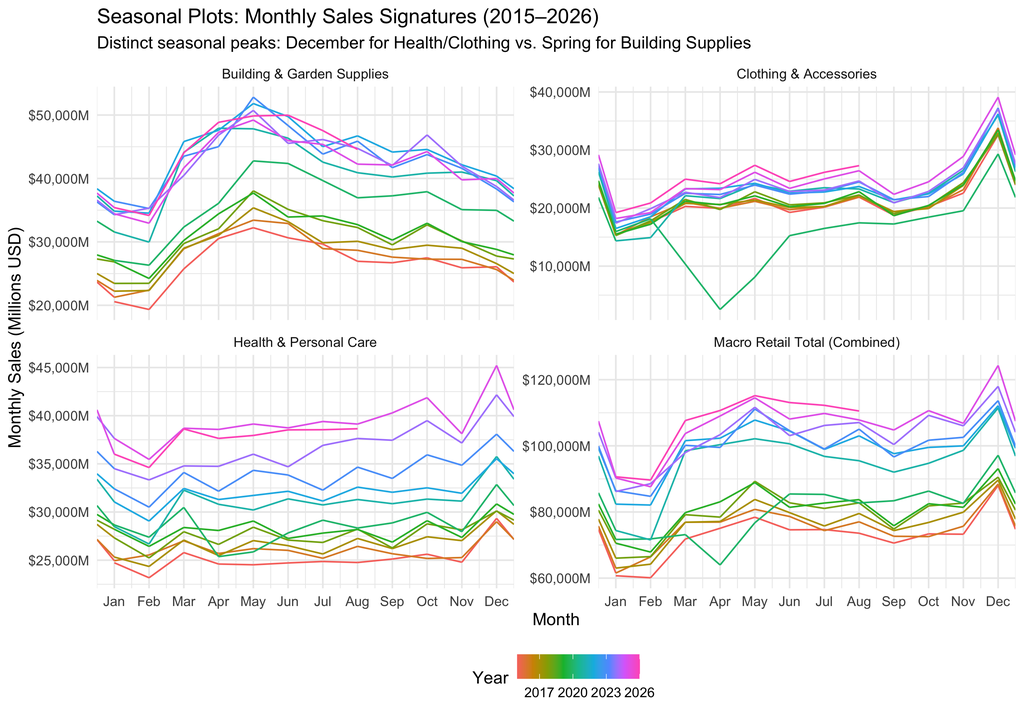

```r
# Seasonal plot by month of year (recent 10 years for clarity)
# Setting labels = "none" ensures the x-axis shows exactly Jan through Dec without padding extra Dec/Jan ticks
retail_ts |>
  filter(Month >= yearmonth("2015 Jan")) |>
  gg_season(sales_nominal, labels = "none") +
  facet_wrap(vars(vertical_name), scales = "free_y") +
  scale_y_continuous(labels = dollar_format(suffix = "M")) +
  labs(
    title = "Seasonal Plots: Monthly Sales Signatures (2015–2026)",
    subtitle = "Distinct seasonal peaks: December for Health/Clothing vs. Spring for Building Supplies",
    y = "Monthly Sales (Millions USD)",
    x = "Month",
    color = "Year"
  ) +
  theme(legend.position = "bottom")
```

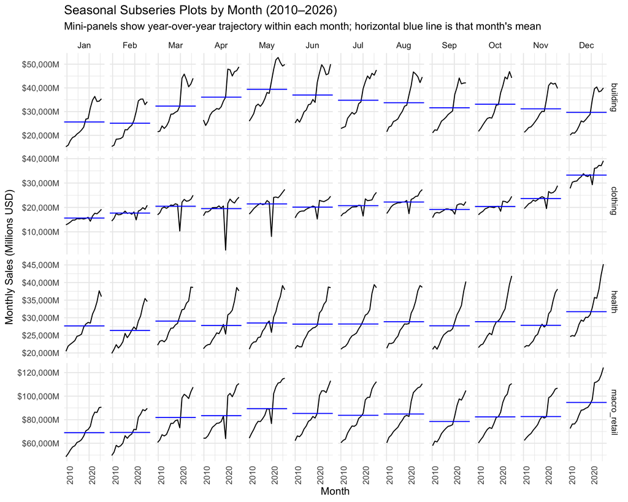

```r
# Seasonal subseries plot showing monthly averages and trends within each calendar month
# (gg_subseries natively formats a 2D grid of 12 month columns across verticals)
retail_ts |>
  filter(Month >= yearmonth("2010 Jan")) |>
  gg_subseries(sales_nominal) +
  scale_y_continuous(labels = dollar_format(suffix = "M")) +
  labs(
    title = "Seasonal Subseries Plots by Month (2010–2026)",
    subtitle = "Mini-panels show year-over-year trajectory within each month; horizontal blue line is that month's mean",
    y = "Monthly Sales (Millions USD)"
  )
```

## 4.3 Outlier Detection & Structural Shocks

To address the Module 4 rubric requirements regarding outliers and structural disruptions, we conduct two diagnostic screens:

1. **Monthly Seasonal Boxplots:** Evaluating dispersion and identifying extreme observations across the 12 calendar months.

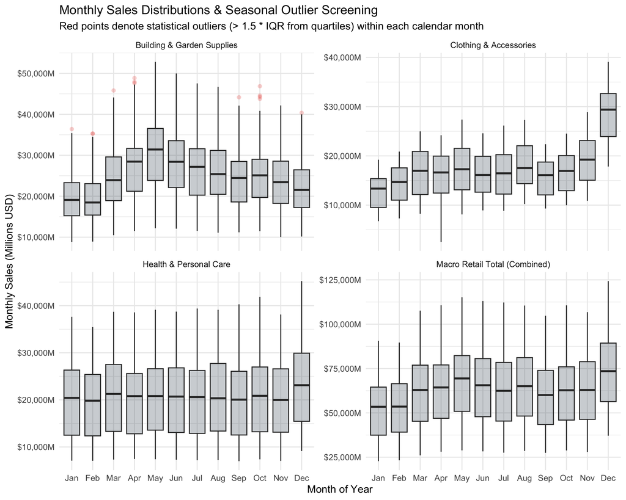

```r
# 1. Monthly Distribution Boxplots (detecting calendar month outliers)
retail_ts |>
  mutate(Month_Label = factor(month(Month, label = TRUE, abbr = TRUE))) |>
  ggplot(aes(x = Month_Label, y = sales_nominal)) +
  geom_boxplot(fill = "#2c3e50", alpha = 0.25, outlier.colour = "#e74c3c", outlier.shape = 16, outlier.size = 2) +
  facet_wrap(vars(vertical_name), scales = "free_y") +
  scale_y_continuous(labels = dollar_format(suffix = "M")) +
  labs(
    title = "Monthly Sales Distributions & Seasonal Outlier Screening",
    subtitle = "Red points denote statistical outliers (> 1.5 * IQR from quartiles) within each calendar month",
    x = "Month of Year",
    y = "Monthly Sales (Millions USD)"
  )
```

```r
# 2. Extract STL Remainder Outliers (|z| > 3)
stl_outliers <- retail_ts |>
  model(stl = STL(sales_nominal ~ season(window = "periodic"))) |>
  components() |>
  as_tibble() |>
  group_by(vertical) |>
  mutate(
    rem_mean = mean(remainder, na.rm = TRUE),
    rem_sd   = sd(remainder, na.rm = TRUE),
    z_score  = (remainder - rem_mean) / rem_sd
  ) |>
  filter(abs(z_score) > 3) |>
  mutate(
    `Retail Vertical` = case_when(
      vertical == "health"       ~ "Health & Personal Care",
      vertical == "clothing"     ~ "Clothing & Accessories",
      vertical == "building"     ~ "Building & Garden Supplies",
      vertical == "macro_retail" ~ "Macro Retail Total (Combined)"
    ),
    `Timestamp`       = format(Month, "%Y %b"),
    `Actual Sales`    = sales_nominal,
    `STL Remainder`   = remainder,
    `Shock Magnitude` = z_score
  ) |>
  ungroup() |>
  select(`Retail Vertical`, `Timestamp`, `Actual Sales`, `STL Remainder`, `Shock Magnitude`) |>
  arrange(`Retail Vertical`, desc(abs(`Shock Magnitude`)))

stl_outliers |>
  head(10) |>
  gt() |>
  tab_header(
    title = md("**Extreme Remainder Outliers (|z-score| > 3)**"),
    subtitle = "Capturing historic structural shocks: COVID-19 pandemic disruptions (Spring 2020) and holiday surges"
  ) |>
  fmt_currency(columns = c(`Actual Sales`, `STL Remainder`), decimals = 0, suffixing = TRUE) |>
  fmt_number(columns = `Shock Magnitude`, decimals = 2, force_sign = TRUE) |>
  cols_align(align = "center", columns = c(`Timestamp`, `Shock Magnitude`)) |>
  tab_options(
    data_row.padding = px(3),
    heading.title.font.size = "13pt",
    heading.subtitle.font.size = "10pt"
  )
```

**Extreme Remainder Outliers (|z-score| > 3)**

Capturing historic structural shocks: COVID-19 pandemic disruptions (Spring 2020) and holiday surges

| Retail Vertical | Timestamp | Actual Sales | STL Remainder | Shock Magnitude |
| --- | --- | --- | --- | --- |
| Building & Garden Supplies | 2021 Apr | $48K | $5K | +3.58 |
| Building & Garden Supplies | 2021 Mar | $44K | $4K | +3.26 |
| Building & Garden Supplies | 2023 May | $53K | $4K | +3.18 |
| Building & Garden Supplies | 2021 Feb | $30K | −$4K | −3.07 |
| Building & Garden Supplies | 1992 May | $12K | −$4K | −3.00 |
| Clothing & Accessories | 2020 Apr | $3K | −$12K | −10.60 |
| Clothing & Accessories | 2020 May | $8K | −$8K | −6.58 |
| Clothing & Accessories | 2020 Mar | $10K | −$5K | −4.51 |
| Clothing & Accessories | 2020 Feb | $18K | $4K | +3.64 |
| Clothing & Accessories | 2019 Dec | $33K | $4K | +3.62 |

## 4.4 Classical Moving Average Smoothing ($2 \times 12$-MA)

Classical moving average smoothing is applied to filter out high-frequency annual fluctuations. For monthly data with even seasonality ($m = 12$), a centered $2 \times 12$-MA is computed using `slider::slide_dbl()`, yielding an unbiased estimate of the underlying macroeconomic trend-cycle.

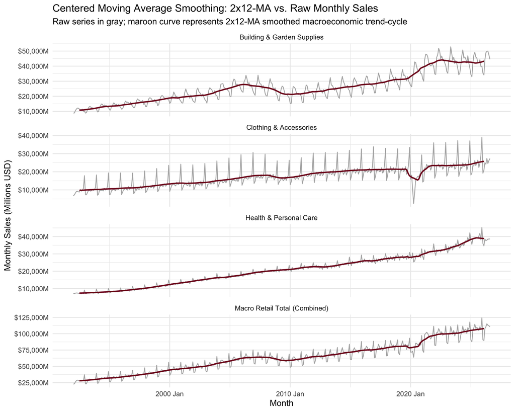

```r
# Compute centered 2x12-MA across each vertical
retail_ma <- retail_ts |>
  group_by(vertical) |>
  mutate(
    ma_12   = slider::slide_dbl(sales_nominal, mean, .before = 5, .after = 6, .complete = TRUE),
    ma_2x12 = slider::slide_dbl(ma_12, mean, .before = 1, .after = 0, .complete = TRUE)
  ) |>
  ungroup()

# Plot raw series against 2x12-MA smoothed trend
retail_ma |>
  autoplot(sales_nominal, colour = "gray70") +
  geom_line(aes(y = ma_2x12), colour = "#800020", linewidth = 0.9) +
  facet_wrap(vars(vertical_name), scales = "free_y", ncol = 1) +
  scale_y_continuous(labels = dollar_format(suffix = "M")) +
  labs(
    title = "Centered Moving Average Smoothing: 2x12-MA vs. Raw Monthly Sales",
    subtitle = "Raw series in gray; maroon curve represents 2x12-MA smoothed macroeconomic trend-cycle",
    y = "Monthly Sales (Millions USD)",
    x = "Month"
  )
```

## 4.5 Autocorrelation & Serial Correlation (ACF)

The ACF diagnostic reveals strong positive persistence and clear 12-month annual seasonal spikes ($r_{12}, r_{24}, r_{36}$).

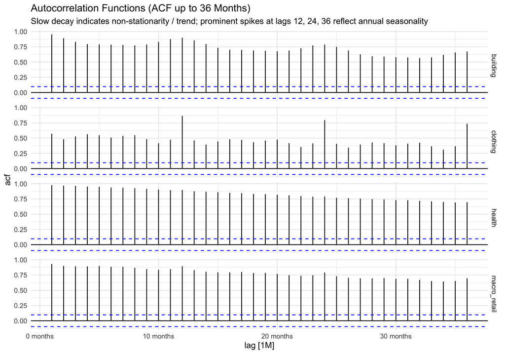

```r
# Autocorrelation function (ACF) across verticals (automatically faceted by key)
retail_ts |>
  ACF(sales_nominal, lag_max = 36) |>
  autoplot() +
  labs(
    title = "Autocorrelation Functions (ACF up to 36 Months)",
    subtitle = "Slow decay indicates non-stationarity / trend; prominent spikes at lags 12, 24, 36 reflect annual seasonality"
  )
```